# R Notebook

Carina Huerta

# 9 Introduction

- You will learn about tibbles, data import, tidy data, relational data, strings, factors, data and times

# 10 Tibbles

- Tibbles are data frames ### 10.1.1

```r
library(tidyverse)
library(magrittr)
library(ggplot2)
```

- had to download magrittr in order to be able to use %>% ## 10.2 Creating tibbles

```r
as_tibble(iris)
```

| Sepal.Length | Sepal.Width | Petal.Length | Petal.Width | Species |
| --- | --- | --- | --- | --- |
| 5.1 | 3.5 | 1.4 | 0.2 | setosa |
| 4.9 | 3.0 | 1.4 | 0.2 | setosa |
| 4.7 | 3.2 | 1.3 | 0.2 | setosa |
| 4.6 | 3.1 | 1.5 | 0.2 | setosa |
| 5.0 | 3.6 | 1.4 | 0.2 | setosa |
| 5.4 | 3.9 | 1.7 | 0.4 | setosa |
| 4.6 | 3.4 | 1.4 | 0.3 | setosa |
| 5.0 | 3.4 | 1.5 | 0.2 | setosa |
| 4.4 | 2.9 | 1.4 | 0.2 | setosa |
| 4.9 | 3.1 | 1.5 | 0.1 | setosa |

[output cut: 140 more lines]

```r
tibble(
  x = 1:5,
  y = 1,
  z = x ^ 2 + y
)
```

| x | y | z |
| --- | --- | --- |
| 1 | 1 | 2 |
| 2 | 1 | 5 |
| 3 | 1 | 10 |
| 4 | 1 | 17 |
| 5 | 1 | 26 |

- non-syntactic names - possible for a tibble to have column names that are not valid R variable names

```r
tb <- tibble(
  `:)` = "smile",
  ` ` = "space",
  `2000` = "number"
)
tb
```

| :) |  | 2000 |
| --- | --- | --- |
| smile | space | number |

- tribble() is customised for data entry in code: column headings are defined by formulas and entries are separated by commas.

```r
tribble(
  ~x, ~y, ~z,
  #--|--|----
  "a", 2, 3.6,
  "b", 1, 8.5
)
```

| x | y | z |
| --- | --- | --- |
| a | 2 | 3.6 |
| b | 1 | 8.5 |

## 10.3 Tibbles vs. data.frame

### 10.3.1 Printing

- Tibbles have a refined print method that shows only the first 10 rows, and all the columns that fit on screen.

```r
tibble(
  a = lubridate::now() + runif(1e3) * 86400,
  b = lubridate::today() + runif(1e3) * 30,
  c = 1:1e3,
  d = runif(1e3),
  e = sample(letters, 1e3, replace = TRUE)
)
```

| a | b | c | d | e |
| --- | --- | --- | --- | --- |
| 2020-03-13 01:32:49 | 2020-04-10 | 1 | 0.3043351078 | k |
| 2020-03-12 21:58:26 | 2020-04-07 | 2 | 0.3553327019 | f |
| 2020-03-13 01:43:07 | 2020-04-03 | 3 | 0.6585351902 | g |
| 2020-03-12 23:58:59 | 2020-03-14 | 4 | 0.5699439968 | z |
| 2020-03-12 22:11:20 | 2020-04-02 | 5 | 0.2448904114 | d |
| 2020-03-13 13:45:46 | 2020-03-19 | 6 | 0.5376023315 | h |
| 2020-03-13 04:20:09 | 2020-03-21 | 7 | 0.6892690144 | j |
| 2020-03-13 13:49:26 | 2020-03-27 | 8 | 0.9434695614 | v |
| 2020-03-13 00:58:16 | 2020-03-26 | 9 | 0.8091984398 | o |
| 2020-03-13 01:13:35 | 2020-03-14 | 10 | 0.4732043315 | l |

[output cut: 990 more lines]

- Tibbles are designed so that you don’t overwhelm your console when you print large data frames.
  - First, you can explicitly print() the data frame and control the number of rows (n) and the width of the display. width = Inf will display all columns

```r
nycflights13::flights %>%
  print(n = 10, width = Inf)
```

| year | month | day | dep_time | sched_dep_time | dep_delay | arr_time | sched_arr_time | arr_delay | carrier | flight | tailnum | origin | dest | air_time | distance | hour | minute | time_hour |
| --- | --- | --- | --- | --- | --- | --- | --- | --- | --- | --- | --- | --- | --- | --- | --- | --- | --- | --- |
| 2013 | 1 | 1 | 517 | 515 | 2 | 830 | 819 | 11 | UA | 1545 | N14228 | EWR | IAH | 227 | 1400 | 5 | 15 | 2013-01-01 05:00:00 |
| 2013 | 1 | 1 | 533 | 529 | 4 | 850 | 830 | 20 | UA | 1714 | N24211 | LGA | IAH | 227 | 1416 | 5 | 29 | 2013-01-01 05:00:00 |
| 2013 | 1 | 1 | 542 | 540 | 2 | 923 | 850 | 33 | AA | 1141 | N619AA | JFK | MIA | 160 | 1089 | 5 | 40 | 2013-01-01 05:00:00 |
| 2013 | 1 | 1 | 544 | 545 | -1 | 1004 | 1022 | -18 | B6 | 725 | N804JB | JFK | BQN | 183 | 1576 | 5 | 45 | 2013-01-01 05:00:00 |
| 2013 | 1 | 1 | 554 | 600 | -6 | 812 | 837 | -25 | DL | 461 | N668DN | LGA | ATL | 116 | 762 | 6 | 0 | 2013-01-01 06:00:00 |
| 2013 | 1 | 1 | 554 | 558 | -4 | 740 | 728 | 12 | UA | 1696 | N39463 | EWR | ORD | 150 | 719 | 5 | 58 | 2013-01-01 05:00:00 |
| 2013 | 1 | 1 | 555 | 600 | -5 | 913 | 854 | 19 | B6 | 507 | N516JB | EWR | FLL | 158 | 1065 | 6 | 0 | 2013-01-01 06:00:00 |
| 2013 | 1 | 1 | 557 | 600 | -3 | 709 | 723 | -14 | EV | 5708 | N829AS | LGA | IAD | 53 | 229 | 6 | 0 | 2013-01-01 06:00:00 |
| 2013 | 1 | 1 | 557 | 600 | -3 | 838 | 846 | -8 | B6 | 79 | N593JB | JFK | MCO | 140 | 944 | 6 | 0 | 2013-01-01 06:00:00 |
| 2013 | 1 | 1 | 558 | 600 | -2 | 753 | 745 | 8 | AA | 301 | N3ALAA | LGA | ORD | 138 | 733 | 6 | 0 | 2013-01-01 06:00:00 |

[output cut: 990 more lines]

```r
nycflights13::flights %>%
  View()
```

## 10.3.2 Subsetting

- to pull out a single variable, you need some new tools, $ and [[. [[ can extract by name or position; $ only extracts by name

```r
df <- tibble(
  x = runif(5),
  y = rnorm(5)
)
df$x
```

```
[1] 0.2035400 0.5819712 0.5246985 0.0216063 0.6315162
```

```r
df[["x"]]
```

```
[1] 0.2035400 0.5819712 0.5246985 0.0216063 0.6315162
```

```r
df[[1]]
```

```
[1] 0.2035400 0.5819712 0.5246985 0.0216063 0.6315162
```

- To use these in a pipe, you’ll need to use the special placeholder ‘.’

```r
df %>% .$x
```

```
[1] 0.2035400 0.5819712 0.5246985 0.0216063 0.6315162
```

```r
df %>% .[["x"]]
```

```
[1] 0.2035400 0.5819712 0.5246985 0.0216063 0.6315162
```

## 10.4 Interacting with older code

```r
class(as.data.frame(tb))
```

```
[1] "data.frame"
```

- With base R data frames, [ sometimes returns a data frame, and sometimes returns a vector

## 10.5 Exercises

1).

- A tibble will print out the first ten observations

```r
mtcars
```

|  | mpg | cyl | disp | hp | drat | wt | qsec | vs | am | gear | carb |
| --- | --- | --- | --- | --- | --- | --- | --- | --- | --- | --- | --- |
| Mazda RX4 | 21.0 | 6 | 160.0 | 110 | 3.90 | 2.620 | 16.46 | 0 | 1 | 4 | 4 |
| Mazda RX4 Wag | 21.0 | 6 | 160.0 | 110 | 3.90 | 2.875 | 17.02 | 0 | 1 | 4 | 4 |
| Datsun 710 | 22.8 | 4 | 108.0 | 93 | 3.85 | 2.320 | 18.61 | 1 | 1 | 4 | 1 |
| Hornet 4 Drive | 21.4 | 6 | 258.0 | 110 | 3.08 | 3.215 | 19.44 | 1 | 0 | 3 | 1 |
| Hornet Sportabout | 18.7 | 8 | 360.0 | 175 | 3.15 | 3.440 | 17.02 | 0 | 0 | 3 | 2 |
| Valiant | 18.1 | 6 | 225.0 | 105 | 2.76 | 3.460 | 20.22 | 1 | 0 | 3 | 1 |
| Duster 360 | 14.3 | 8 | 360.0 | 245 | 3.21 | 3.570 | 15.84 | 0 | 0 | 3 | 4 |
| Merc 240D | 24.4 | 4 | 146.7 | 62 | 3.69 | 3.190 | 20.00 | 1 | 0 | 4 | 2 |
| Merc 230 | 22.8 | 4 | 140.8 | 95 | 3.92 | 3.150 | 22.90 | 1 | 0 | 4 | 2 |
| Merc 280 | 19.2 | 6 | 167.6 | 123 | 3.92 | 3.440 | 18.30 | 1 | 0 | 4 | 4 |

[output cut: 22 more lines]

```r
as_tibble(mtcars)
```

|  | mpg | cyl | disp | hp | drat | wt | qsec | vs | am | gear | carb |
| --- | --- | --- | --- | --- | --- | --- | --- | --- | --- | --- | --- |
| 1 | 21.0 | 6 | 160.0 | 110 | 3.90 | 2.620 | 16.46 | 0 | 1 | 4 | 4 |
| 2 | 21.0 | 6 | 160.0 | 110 | 3.90 | 2.875 | 17.02 | 0 | 1 | 4 | 4 |
| 3 | 22.8 | 4 | 108.0 | 93 | 3.85 | 2.320 | 18.61 | 1 | 1 | 4 | 1 |
| 4 | 21.4 | 6 | 258.0 | 110 | 3.08 | 3.215 | 19.44 | 1 | 0 | 3 | 1 |
| 5 | 18.7 | 8 | 360.0 | 175 | 3.15 | 3.440 | 17.02 | 0 | 0 | 3 | 2 |
| 6 | 18.1 | 6 | 225.0 | 105 | 2.76 | 3.460 | 20.22 | 1 | 0 | 3 | 1 |
| 7 | 14.3 | 8 | 360.0 | 245 | 3.21 | 3.570 | 15.84 | 0 | 0 | 3 | 4 |
| 8 | 24.4 | 4 | 146.7 | 62 | 3.69 | 3.190 | 20.00 | 1 | 0 | 4 | 2 |
| 9 | 22.8 | 4 | 140.8 | 95 | 3.92 | 3.150 | 22.90 | 1 | 0 | 4 | 2 |
| 10 | 19.2 | 6 | 167.6 | 123 | 3.92 | 3.440 | 18.30 | 1 | 0 | 4 | 4 |

[output cut: 22 more lines]

2).

```r
df <- data.frame(abc = 1, xyz = "a")
df$x
```

```
[1] a
Levels: a
```

```r
df[, "xyz"]
```

```
[1] a
Levels: a
```

```r
df[, c("abc", "xyz")]
```

| abc | xyz |
| --- | --- |
| 1 | a |

- The $ operator will match any column name that starts with the name following it
- With data.frames, with [ the type of object that is returned differs on the number of columns

3). If you have the name of a variable stored in an object, e.g. var <- “mpg”, how can you extract the reference variable from a tibble? in order to extract the variable you would use the double bracket - like df[[var]] cannot use the dollar sign because df$var would look for a column named var

4).

```r
annoying <- tibble(
  `1` = 1:10,
  `2` = `1` * 2 + rnorm(length(`1`))
)
```

extrat ariable 1

```r
annoying[["1"]]
```

```
 [1]  1  2  3  4  5  6  7  8  9 10
```

create a scatter plot of 1 vs. 2

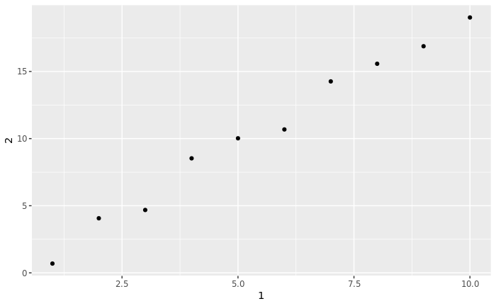

```r
ggplot(annoying, aes(x = `1`, y = `2`)) +
  geom_point()
```

add a new column 3 which is 2 divided by 1

```r
annoying[["3"]] <- annoying[["2"]] / annoying[["1"]]
```

rename the columns to one, two, and three, run

```r
annoying <- rename(annoying, one = `1`, two = `2`, three = `3`)
glimpse(annoying)
```

5).

- The function tibble::enframe() converts named vectors to a data frame with names and values

6).

- x - Object to show
- n - Number of rows to show. If NULL, the default, will print all rows if less than option tibble.print_max. Otherwise, will print tibble.print_min rows
- width - Width of text output to generate. This defaults to NULL, which means use getOption(“tibble.width”) or (if also NULL) getOption(“width”); the latter displays only the columns that fit on one screen. You can also set options(tibble.width = Inf) to override this default and always print all columns
- n_extra - Number of extra columns to print abbreviated information for, if the width is too small for the entire tibble. If NULL, the default, will print information about at most tibble.max_extra_cols extra columns

# 11 Data import

## 11.2 Getting started

- read_csv() reads comma delimited files, read_csv2() reads semicolon separated files (common in countries where , is used as the decimal place), read_tsv() reads tab delimited files, and read_delim() reads in files with any delimiter.
- read_fwf() reads fixed width files. You can specify fields either by their widths with fwf_widths() or their position with fwf_positions()
- read_table() reads a common variation of fixed width files where columns are separated by white space.
- read_log() reads Apache style log files
- (But also check out webreadr which is built on top of read_log() and provides many more helpful tools.)

```r
heights<-read_csv("data/heights.csv")
read_csv("a,b,c
1,2,3
4,5,6")
```

```r
read_csv("The first line of metadata
  The second line of metadata
  x,y,z
  1,2,3", skip = 2)
```

### 11.2.1 Exercises

1).

- read_delim() function with the argument delim=“|”

```r
read_delim(file, delim = "|")
```

2).

```r
union(names(formals(read_csv)), names(formals(read_tsv)))
```

3).

- read_fwf() which reads “fixed-width formats”, is col_positions which tells the function where data columns begin and end

5).

```r
read_csv("a,b\n1,2,3\n4,5,6")
```

two columns are specified in the header “a” and “b” the rows have three columns, so the last column is dropped.

```r
read_csv("a,b,c\n1,2\n1,2,3,4")
```

[output not shown]

numbers of columns in the data do not match the number of columns in the header (three) row one, there are only two values, so column c is set to missing row two, there is an extra value, and that value is dropped.

```r
read_csv("a,b\n\"1")
```

opening quote “1 is dropped because it is not closed, and a is treated as an integer.

```r
read_csv("a,b\n1,2\na,b")
```

“a” and “b” are treated as character vectors since they contain non-numeric strings.

```r
read_csv("a;b\n1;3")
```

values are separated by “;” instead of “,”.

## 11.3 Parsing a vector

```r
str(parse_logical(c("TRUE", "FALSE", "NA")))
str(parse_integer(c("1", "2", "3")))
str(parse_date(c("2010-01-01", "1979-10-14")))
parse_integer(c("1", "231", ".", "456"), na = ".")
x <- parse_integer(c("123", "345", "abc", "123.45"))
```

- parse_logical() and parse_integer() parse logicals and integers respectively. There’s basically nothing that can go wrong with these parsers so I won’t describe them here further.
- parse_double() is a strict numeric parser, and parse_number() is a flexible numeric parser. These are more complicated than you might expect because different parts of the world write numbers in different ways.
- parse_character() seems so simple that it shouldn’t be necessary. But one complication makes it quite important: character encodings.
- parse_factor() create factors, the data structure that R uses to represent categorical variables with fixed and known values.
- parse_datetime(), parse_date(), and parse_time() allow you to parse various date & time specifications. These are the most complicated because there are so many different ways of writing dates.

### 11.3.1 Exercises

1).

- date and time formats: date_names, date_format, and time_format
- time zone: tz
- numbers: decimal_mark, grouping_mark
- encoding: encoding 2).

decimal_mark is set to the comma “,”, then the grouping mark is set to the period “.” If the grouping mark is set to a period, then the decimal mark is set to a comma

3).

```r
au_locale <- locale(date_format = "%d/%m/%Y")
parse_date("02/01/2006", locale = au_locale)
```

5).

delimiter. The function read_csv() uses a comma, while read_csv2() uses a semi-colon (;) Using a semi-colon is useful when commas are used as the decimal point (as in Europe). 6).

Programs that identify the encoding of text include:

- readr::guess_encoding()
- stringi::str_enc_detect()
- iconv
- chardet (Python)

7).

```r
parse_date(d1, "%B %d, %Y")
parse_date(d2, "%Y-%b-%d")
parse_date(d3, "%d-%b-%Y")
parse_date(d4, "%B %d (%Y)")
parse_date(d5, "%m/%d/%y")
parse_time(t1, "%H%M")
```

## 11.4 Parsing a file

```r
guess_parser("2010-10-01")
guess_parser("15:01")
guess_parser(c("TRUE", "FALSE"))
guess_parser(c("1", "5", "9"))
guess_parser(c("12,352,561"))
str(parse_guess("2010-10-10"))
```

- logical: contains only “F”, “T”, “FALSE”, or “TRUE”.
- integer: contains only numeric characters (and -).
- double: contains only valid doubles (including numbers like 4.5e-5).
- number: contains valid doubles with the grouping mark inside.
- time: matches the default time_format.
- date: matches the default date_format.
- date-time: any ISO8601 date.

## 11.5 Writing to a file

```r
write_csv(challenge, "challenge.csv")
```

- write_rds() and read_rds() are uniform wrappers around the base functions readRDS() and saveRDS()

```r
write_rds(challenge, "challenge.rds")
```

[output not shown]

## 11.6 Other types of data

- haven reads SPSS, Stata, and SAS files.
- readxl reads excel files (both .xls and .xlsx).
- DBI, along with a database specific backend allows you to run SQL queries against a database and return a data frame.